# CS 422

Juan Luis Polo, Student, Illinois Institute of Technology

## Problem 2.1: Decision tree classification

```r
library(rpart)
library(caret)
library(rpart.plot)
library(ROCR)
library(pROC)

setwd("/Users/juanluispolog/Google Drive/CS422/homework2")
adult.train <- read.csv("adult-train.csv")
adult.test <- read.csv("adult-test.csv")
```

### Part A

Cleaning the *adult.train* dataframe. Final result 30161 rows.

```r
str(adult.train)
```

```
'data.frame':   32560 obs. of  15 variables:
 $ age           : int  39 50 38 53 28 37 49 52 31 42 ...
 $ workclass     : Factor w/ 9 levels "?","Federal-gov",..: 8 7 5 5 5 5 5 7 5 5 ...
 $ fnlwgt        : int  77516 83311 215646 234721 338409 284582 160187 209642 45781 159449 ...
 $ education     : Factor w/ 16 levels "10th","11th",..: 10 10 12 2 10 13 7 12 13 10 ...
 $ education_num : int  13 13 9 7 13 14 5 9 14 13 ...
 $ marital_status: Factor w/ 7 levels "Divorced","Married-AF-spouse",..: 5 3 1 3 3 3 4 3 5 3 ...
 $ occupation    : Factor w/ 15 levels "?","Adm-clerical",..: 2 5 7 7 11 5 9 5 11 5 ...
 $ relationship  : Factor w/ 6 levels "Husband","Not-in-family",..: 2 1 2 1 6 6 2 1 2 1 ...
 $ race          : Factor w/ 5 levels "Amer-Indian-Eskimo",..: 5 5 5 3 3 5 3 5 5 5 ...
 $ sex           : Factor w/ 2 levels "Female","Male": 2 2 2 2 1 1 1 2 1 2 ...
 $ capital_gain  : int  2174 0 0 0 0 0 0 0 14084 5178 ...
 $ capital_loss  : int  0 0 0 0 0 0 0 0 0 0 ...
 $ hours_per_week: int  40 13 40 40 40 40 16 45 50 40 ...
 $ native_country: Factor w/ 41 levels "?","Cambodia",..: 39 39 39 39 6 39 23 39 39 39 ...
 $ income        : Factor w/ 2 levels "<=50K",">50K": 1 1 1 1 1 1 1 2 2 2 ...
```

```r
adult.train.new <- adult.train[-c(which(adult.train$workclass == '?'),
                           which(adult.train$occupation == '?'),
                           which(adult.train$native_country == '?')), ]
```

Cleaning the *adult.test* dataframe. Final result 15060 rows.

```r
str(adult.test)
```

```
'data.frame':   16281 obs. of  15 variables:
 $ age           : int  25 38 28 44 18 34 29 63 24 55 ...
 $ workclass     : Factor w/ 9 levels "?","Federal-gov",..: 5 5 3 5 1 5 1 7 5 5 ...
 $ fnlwgt        : int  226802 89814 336951 160323 103497 198693 227026 104626 369667 104996 ...
 $ education     : Factor w/ 16 levels "10th","11th",..: 2 12 8 16 16 1 12 15 16 6 ...
 $ education_num : int  7 9 12 10 10 6 9 15 10 4 ...
 $ marital_status: Factor w/ 7 levels "Divorced","Married-AF-spouse",..: 5 3 3 3 5 5 5 3 5 3 ...
 $ occupation    : Factor w/ 15 levels "?","Adm-clerical",..: 8 6 12 8 1 9 1 11 9 4 ...
 $ relationship  : Factor w/ 6 levels "Husband","Not-in-family",..: 4 1 1 1 4 2 5 1 5 1 ...
 $ race          : Factor w/ 5 levels "Amer-Indian-Eskimo",..: 3 5 5 3 5 5 3 5 5 5 ...
 $ sex           : Factor w/ 2 levels "Female","Male": 2 2 2 2 1 2 2 2 1 2 ...
 $ capital_gain  : int  0 0 0 7688 0 0 0 3103 0 0 ...
 $ capital_loss  : int  0 0 0 0 0 0 0 0 0 0 ...
 $ hours_per_week: int  40 50 40 40 30 30 40 32 40 10 ...
 $ native_country: Factor w/ 41 levels "?","Cambodia",..: 39 39 39 39 39 39 39 39 39 39 ...
 $ income        : Factor w/ 2 levels "<=50K",">50K": 1 1 2 2 1 1 1 2 1 1 ...
```

```r
adult.test.new <- adult.test[-c(which(adult.test$workclass == '?'),
                           which(adult.test$occupation == '?'),
                           which(adult.test$native_country == '?')), ]
```

### Part B - I

Creating the decision tree:

```r
adult.model <- rpart(income ~ ., method='class', data=adult.train.new)
```

### Part B - II

Plotting the decision tree:

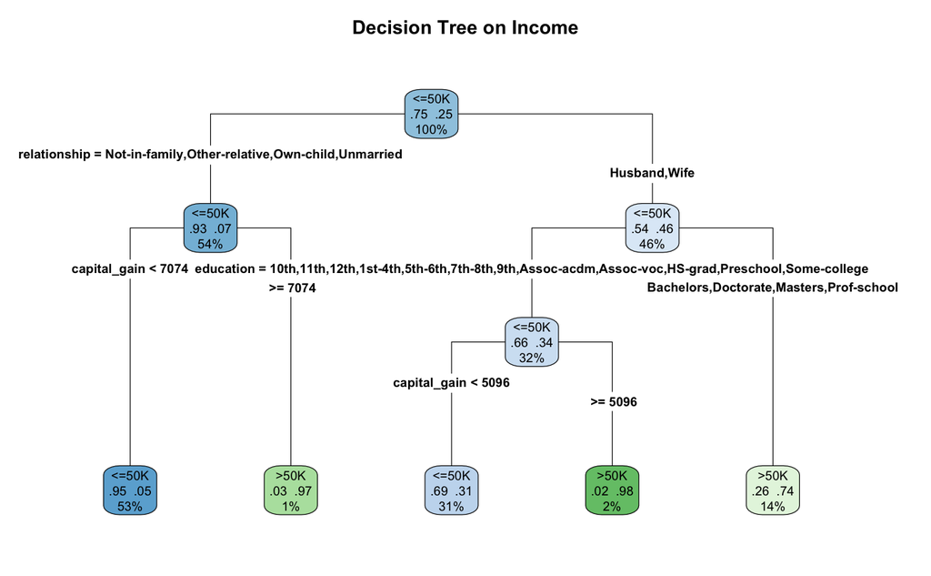

```r
rpart.plot(adult.model, extra = 104, type = 4, fallen.leaves = T, main = "Decision Tree on Income")
```

### Part B - III

Top 3 predictors of the model:

- relationship
- education
- capital-gain

### Part B - IV

The first split of the decision tree is done in:

```r
rownames(adult.model$splits)[1]
```

```
[1] "relationship"
```

As can be observed in the decision tree (part b-II), the predicted class of the first node is *“<=50K”*. In addition, the distribution of observation between *<=50K* and *>50* is **0.75** and **0.25**.

### Part C - I

Prediction for *df.test*

```r
adult.pred <- predict(adult.model, adult.test.new, type = "class")
head(adult.pred)
```

```
    1     2     3     4     6     8
<=50K <=50K <=50K  >50K <=50K  >50K
Levels: <=50K >50K
```

```r
# Create the cofussion matrix automatically
confusionMatrix(adult.pred, adult.test.new$income)
```

```
Confusion Matrix and Statistics

          Reference
Prediction <=50K  >50K
     <=50K 10772  1837
     >50K    588  1863

               Accuracy : 0.839
                 95% CI : (0.833, 0.8448)
    No Information Rate : 0.7543
    P-Value [Acc > NIR] : < 2.2e-16

                  Kappa : 0.5098

 Mcnemar's Test P-Value : < 2.2e-16

            Sensitivity : 0.9482
            Specificity : 0.5035
         Pos Pred Value : 0.8543
         Neg Pred Value : 0.7601
             Prevalence : 0.7543
         Detection Rate : 0.7153
   Detection Prevalence : 0.8373
      Balanced Accuracy : 0.7259

       'Positive' Class : <=50K
```

### Part C - I

The **Balanced Accuracy** of this model is: 0.726.

### Part C - II

The **Balanced Error Rate** of this model is (1 - Balanced Error Rate): 0.274.

### Part C - III

The **sensitivity** is: 0.948. The **specificity** is: 0.503. There is a great difference between sensitivity and specificity due to the imbalanced training dataset.

### Part C - IV

The following code plots the ROC curve and calculates the Area Under the Curve.

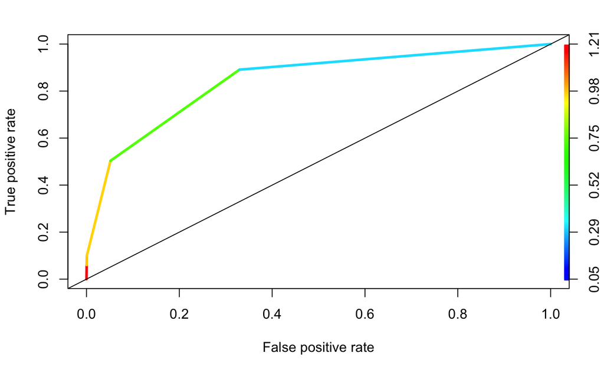

```r
pred.rocr <- predict(adult.model, newdata=adult.test.new, type="prob")[,2]
f.pred <- prediction(pred.rocr, adult.test.new$income)
f.perf <- performance(f.pred, "tpr", "fpr")
plot(f.perf, colorize=T, lwd=3)
abline(0,1)
```

```r
auc <- performance(f.pred, measure = "auc")
cat(paste("The area under curve (AUC) for this model is ", round(auc@y.values[[1]], 3)))
```

```
The area under curve (AUC) for this model is  0.843
```

The area under thr ROC curve is large. Moreover, the ROC curve is close to the desired zone (up-left corner). That means that the model fit quite good the data.

### Part D - I

The train dataset in clearly imbalanced.

```r
cat("Number of values with income <=50K: ", sum(adult.test.new$income == "<=50K"), "\n", fill= T)
```

```
Number of values with income <=50K:  11360
```

```r
cat("Number of values with income >50K: ",sum(adult.test.new$income == ">50K"), "\n", fill= T)
```

```
Number of values with income >50K:  3700
```

### Part D - II

Creating a new train dataset with a balanced class income by taking the same number of rows per income class. As the class *“>50K”* has a lower number of rows, we will take this number of rows from the *“<=50K”* class

```r
n <- sum(adult.train.new$income == ">50K")

more50 <- which(adult.train.new$income == ">50K")
less50 <- which(adult.train.new$income == "<=50K")

sampleLess50 <- sample(less50, n)

adult.train.new2 <- adult.train.new[c(more50, sampleLess50),]
```

### Part D - III

Training a new model for the new train dataset.

```r
adult.model2 <- rpart(income ~ ., method='class', data=adult.train.new2)
```

Fitting the model to the test dataset and calculating the cofussion matrix for these results.

```r
# The test dataset does not change
adult.pred2 <- predict(adult.model2, adult.test.new, type = "class")
# Create the cofussion matrix automatically
confusionMatrix(adult.pred2, adult.test.new$income)
```

```
Confusion Matrix and Statistics

          Reference
Prediction <=50K >50K
     <=50K  8769  607
     >50K   2591 3093

               Accuracy : 0.7876
                 95% CI : (0.781, 0.7942)
    No Information Rate : 0.7543
    P-Value [Acc > NIR] : < 2.2e-16

                  Kappa : 0.5148

 Mcnemar's Test P-Value : < 2.2e-16

            Sensitivity : 0.7719
            Specificity : 0.8359
         Pos Pred Value : 0.9353
         Neg Pred Value : 0.5442
             Prevalence : 0.7543
         Detection Rate : 0.5823
   Detection Prevalence : 0.6226
      Balanced Accuracy : 0.8039

       'Positive' Class : <=50K
```

### Part D - III -I)

The **Balanced Accuracy** of this model is: 0.804.

### Part D - III -II)

The **Balanced Error Rate** of this model is (1 - Balanced Error Rate): 0.196.

### Part D - III -IV)

The following code plots the ROC curve and calculates the Area Under the Curve.

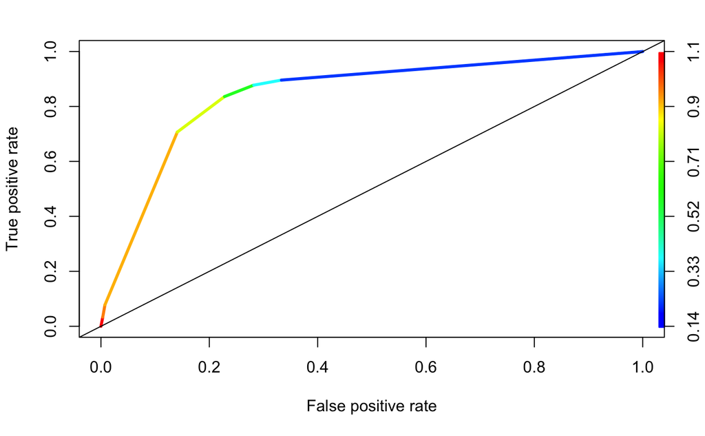

```r
pred.rocr <- predict(adult.model2, newdata=adult.test.new, type="prob")[,2]
f.pred <- prediction(pred.rocr, adult.test.new$income)
f.perf <- performance(f.pred, "tpr", "fpr")
plot(f.perf, colorize=T, lwd=3)
abline(0,1)
```

```r
auc <- performance(f.pred, measure = "auc")
cat(paste("The area under curve (AUC) for this model is ", round(auc@y.values[[1]], 3)))
```

```
The area under curve (AUC) for this model is  0.844
```

The area under the curve is now slightly large than for the previous model (imbalanced model).

### Part E

Parameter values are in line with expectations:

- Balanced Accuracy: Balanced accuracy is clearly higher for the balanced model.
- Sensitivity: Higher for the imbalanced model.
- Specificity: Higher for the balanced model.
- Positive predictive value: Higher for the balanced model.
- AUC: Slightly higher for balanced model.

## Problem 2: Random Forest

```r
# Using randomForest library for this problem
library(randomForest)

set.seed(1122)
```

### Part A

Introducing a random forest on the training dataset:

```r
rf.model <- randomForest(income ~ ., data = adult.train.new)
```

Fitting the test dataset to the random forest model and calculating the confusion matrix of the model:

```r
rf.pred <- predict(rf.model, adult.test.new, type="class")
confusionMatrix(rf.pred, adult.test.new$income)
```

```
Confusion Matrix and Statistics

          Reference
Prediction <=50K  >50K
     <=50K 10572  1341
     >50K    788  2359

               Accuracy : 0.8586
                 95% CI : (0.853, 0.8642)
    No Information Rate : 0.7543
    P-Value [Acc > NIR] : < 2.2e-16

                  Kappa : 0.5984

 Mcnemar's Test P-Value : < 2.2e-16

            Sensitivity : 0.9306
            Specificity : 0.6376
         Pos Pred Value : 0.8874
         Neg Pred Value : 0.7496
             Prevalence : 0.7543
         Detection Rate : 0.7020
   Detection Prevalence : 0.7910
      Balanced Accuracy : 0.7841

       'Positive' Class : <=50K
```

Considering the parameters balanced accuracy, sensitivity and specificity, we can conclude that the model is imbalanced.

### Part B

Grid search changing hyper-parameters:

```r
ntree.values <- c(100, 750)
mtry.values <- c(2, 5, 7)

rf.grid.models <- list()
rf.grid.predictions <- list()
rf.grid.OOB <- list()
rf.grid.OOB.means <- c()
rf.grid.OOB.min <- c()
rf.grid.CM <- list()

n <- 1
for (i in ntree.values) {
  for (j in mtry.values) {
    rf.grid.model <- randomForest(income ~ ., data = adult.test.new, mtry = j, ntree = i)
    rf.grid.prediction <- predict(rf.grid.model, adult.test.new, type ="class")

    rf.grid.models[[n]] <- rf.grid.model
    rf.grid.predictions[[n]] <- rf.grid.prediction

    rf.grid.OOB[[n]] <- rf.grid.model$err.rate[,1]
    rf.grid.OOB.means[n] <- mean(rf.grid.OOB[[n]])
    rf.grid.OOB.min[n] <- min(rf.grid.OOB[[n]])
    rf.grid.CM[[n]] <- confusionMatrix(rf.grid.prediction, adult.test.new$income)

    n <- n+1
  }
}
```

### Part C

Examining the sensitivity, specificity and balanced accuracy model by model.

```r
for (i in 1:6) {
  cat("Model #",i,", (ntree=",rf.grid.models[[i]]$ntree,
      ", mtry=", rf.grid.models[[i]]$mtry,")", "\n", fill = T)
  cat("Sensitivity: ", rf.grid.CM[[i]]$byClass["Sensitivity"], "\n", fill = T)
  cat("Specificity: ", rf.grid.CM[[i]]$byClass["Specificity"], "\n", fill = T)
  cat("Balanced Accuracy: ", rf.grid.CM[[i]]$byClass["Balanced Accuracy"], "\n", "\n", fill = T)
}
```

```
Model # 1 , (ntree= 100 , mtry= 2 )

Sensitivity:  0.9711268

Specificity:  0.7435135

Balanced Accuracy:  0.8573201


Model # 2 , (ntree= 100 , mtry= 5 )

Sensitivity:  0.9992077

Specificity:  0.9867568

Balanced Accuracy:  0.9929823


Model # 3 , (ntree= 100 , mtry= 7 )

Sensitivity:  0.999912

Specificity:  0.9967568

Balanced Accuracy:  0.9983344


Model # 4 , (ntree= 750 , mtry= 2 )

Sensitivity:  0.9691901

Specificity:  0.7513514

Balanced Accuracy:  0.8602707


Model # 5 , (ntree= 750 , mtry= 5 )

Sensitivity:  0.9994718

Specificity:  0.9889189

Balanced Accuracy:  0.9941954


Model # 6 , (ntree= 750 , mtry= 7 )

Sensitivity:  1

Specificity:  0.9994595

Balanced Accuracy:  0.9997297
```

```r
rf.models.Sens <- c()
rf.models.Spec <- c()
rf.models.BA <- c()
for (i in 1:6) {
  rf.models.Sens[i] <- rf.grid.CM[[i]]$byClass["Sensitivity"]
  rf.models.Spec[i] <- rf.grid.CM[[i]]$byClass["Specificity"]
  rf.models.BA[i] <- rf.grid.CM[[i]]$byClass["Balanced Accuracy"]
}

cat("Max Sensitivity: ", max(rf.models.Sens), "\n", fill = T)
```

```
Max Sensitivity:  1
```

```r
cat("Max Specificity: ", max(rf.models.Spec), "\n", fill = T)
```

```
Max Specificity:  0.9994595
```

```r
cat("Max Balanced Accuracy: ", max(rf.models.BA), "\n", fill = T)
```

```
Max Balanced Accuracy:  0.9997297
```

As it can be observed above, the model with maximum Sensitivity, Specificity and Balanced Accuracy is model #6. Thus, taking every parameter into consideration, it could be stated that the **best model** is **model #6**.

### Part D

```r
rf.grid.OOB.means
```

```
[1] 0.1484670 0.1596599 0.1614096 0.1431276 0.1520527 0.1545092
```

```r
cat("Minimum mean OOB error: ", min(rf.grid.OOB.means), "\n", fill = T)
```

```
Minimum mean OOB error:  0.1431276
```

```r
rf.grid.OOB.min
```

```
[1] 0.1429615 0.1527888 0.1531208 0.1411687 0.1484064 0.1513280
```

```r
cat("Minimum OOB error: ", min(rf.grid.OOB.min), "\n", fill = T)
```

```
Minimum OOB error:  0.1411687
```

OOB error can be defined as the mean prediction error of each training sample As it can be observed above, **model #4** has the lowest OOB error. Therefore, this model is the best one.

### Part E

In this case, the best model in terms of performance parameters is model #6, whereas, the model with the minimum mean OOB error is model #4.

It should come out the same model. This may be because some of the models are imbalanced and the OOB error results are not adequate.

## Problem 3: Perceptron

#### Data - 10 observations

As indicated, the perceptron code has been developed for the dataset containing 10 samples. The number of *iterations* has been decided empirically, observing from which iteration the error is zero and the weights are not updated. The value of the *weight update parameter* has been set to 0.5.

```r
data <- read.csv("data-10.csv")

iterations <- 8
x <- data[, c("bias", "x1", "x2")]
class <- data[, "label"]

weight <- rep(0, dim(x)[2])
errors <- rep(0, iterations)

for (j in 1:iterations) {
    for (i in 1:length(class)) {

    # Perceptron predicted value:
    input <- sum(weight[1:length(weight)] * as.numeric(x[i, ]))
    if(input < 0) {
      ypred <- -1
    } else {
      ypred <- 1
    }

    # Weights update
    weight.new <- 0.5 * (class[i] - ypred) * as.numeric(x[i, ])
    weight <- weight + weight.new

    # Error update
    if ((class[i] - ypred) != 0.0) {
      errors[j] <- errors[j] + 1
    }

  }
}

print(weight)
```

```
[1] -1.000  0.973  1.186
```

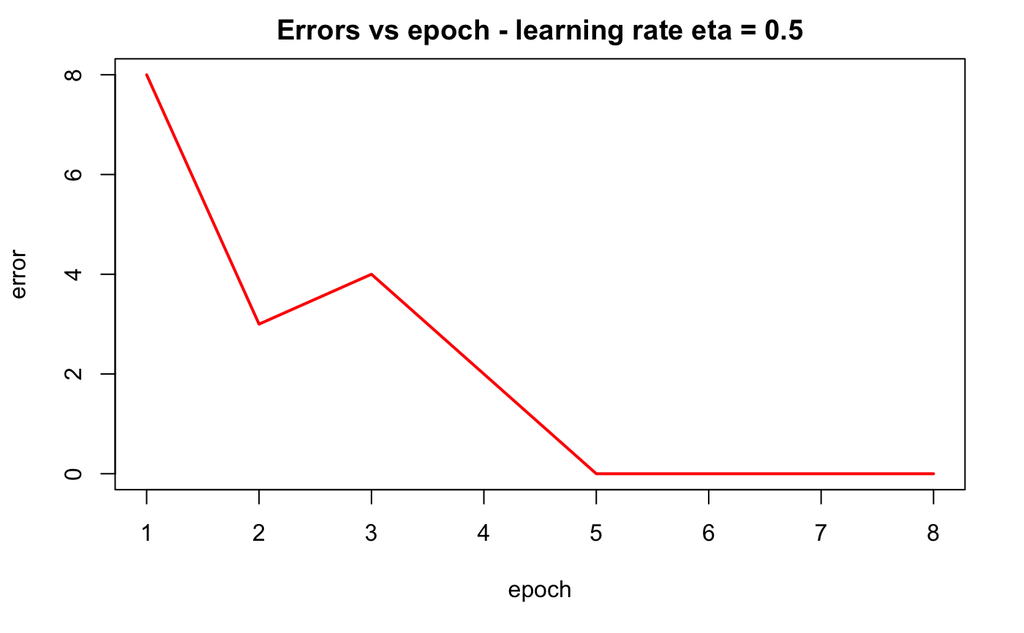

```r
plot(1:iterations, errors, type="l", lwd=2, col="red", xlab="epoch", ylab="error")
title("Errors vs epoch - learning rate eta = 0.5")
```

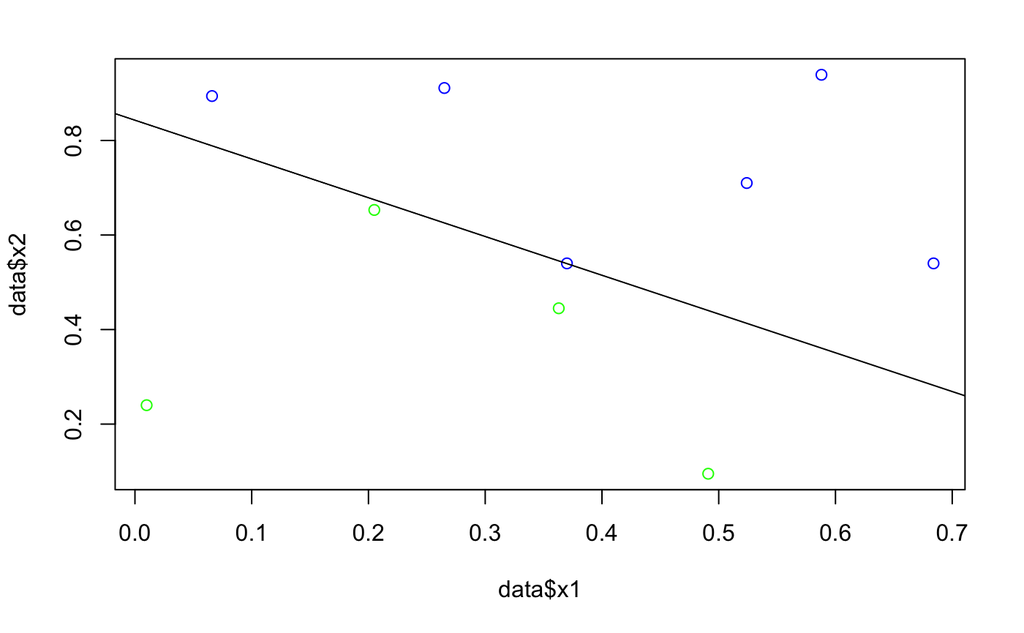

```r
color <- rep("blue", dim(x)[1])
color[which(data$label == -1)] <- "green"

plot(data$x1, data$x2, col=color)

# Following instruction plots the perceptron decision boundary:
# w1 + w2*x1 + w3*x2 = 0
# x2 = -w1/w3 - (w2/w3)*x1
abline(-weight[1]/weight[3],-weight[2]/weight[3])
```

In this case, the **error** is zero from iteration **#5** onwards.

#### Data - 50 observations

```r
data <- read.csv("data-50.csv")

iterations <- 15
x <- data[, c("bias", "x1", "x2")]
class <- data[, "label"]

weight <- rep(0, dim(x)[2])
errors <- rep(0, iterations)

for (j in 1:iterations) {
    for (i in 1:length(class)) {

    # Perceptron predicted value:
    input <- sum(weight[1:length(weight)] * as.numeric(x[i, ]))
    if(input < 0) {
      ypred <- -1
    } else {
      ypred <- 1
    }

    # Weights update
    weight.new <- 0.5 * (class[i] - ypred) * as.numeric(x[i, ])
    weight <- weight + weight.new

    # Error update
    if ((class[i] - ypred) != 0.0) {
      errors[j] <- errors[j] + 1
    }

  }
}

print(weight)
```

```
[1] -4.000  3.976  4.121
```

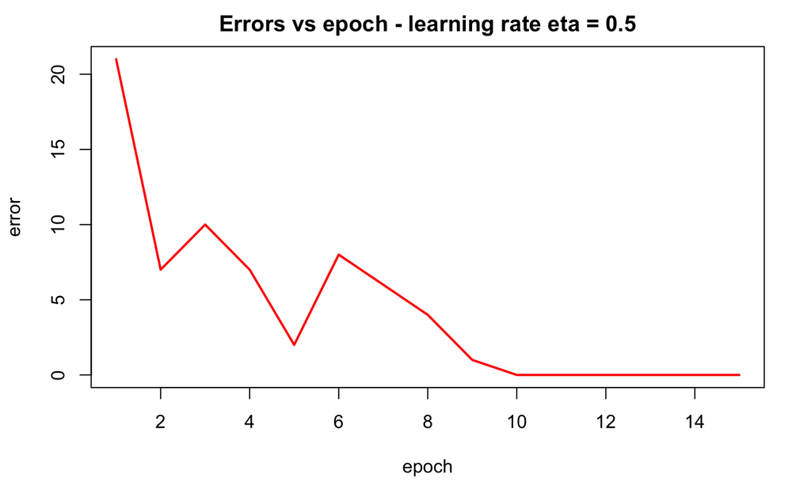

```r
plot(1:iterations, errors, type="l", lwd=2, col="red", xlab="epoch", ylab="error")
title("Errors vs epoch - learning rate eta = 0.5")
```

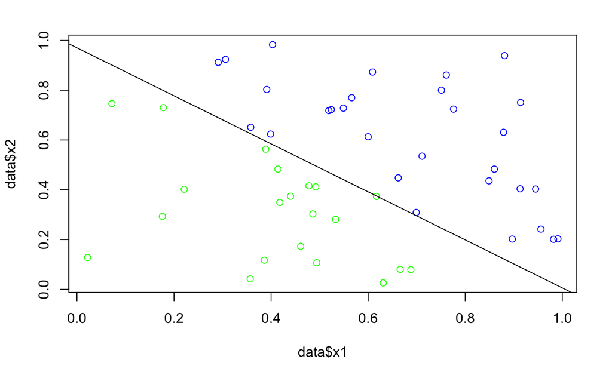

```r
color <- rep("blue", dim(x)[1])
color[which(data$label == -1)] <- "green"

plot(data$x1, data$x2, col=color)

# Following instruction plots the perceptron decision boundary:
# w1 + w2*x1 + w3*x2 = 0
# x2 = -w1/w3 - (w2/w3)*x1
abline(-weight[1]/weight[3],-weight[2]/weight[3])
```

In this case, the **error** is zero from iteration **#10** onwards.

#### Data - 500 observations

```r
data <- read.csv("data-500.csv")

iterations <- 5
x <- data[, c("bias", "x1", "x2")]
class <- data[, "label"]

weight <- rep(0, dim(x)[2])
errors <- rep(0, iterations)

for (j in 1:iterations) {
    for (i in 1:length(class)) {

    # Perceptron predicted value:
    input <- sum(weight[1:length(weight)] * as.numeric(x[i, ]))
    if(input < 0) {
      ypred <- -1
    } else {
      ypred <- 1
    }

    # Weights update
    weight.new <- 0.5 * (class[i] - ypred) * as.numeric(x[i, ])
    weight <- weight + weight.new

    # Error update
    if ((class[i] - ypred) != 0.0) {
      errors[j] <- errors[j] + 1
    }

  }
}

print(weight)
```

```
[1] -6.000  6.035  5.942
```

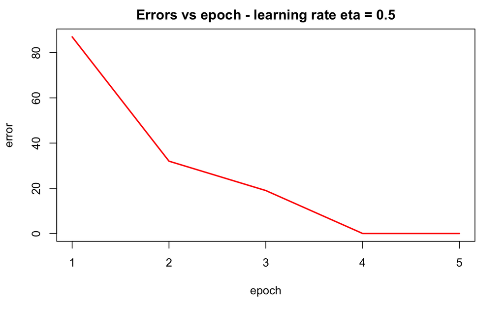

```r
plot(1:iterations, errors, type="l", lwd=2, col="red", xlab="epoch", ylab="error")
title("Errors vs epoch - learning rate eta = 0.5")
```

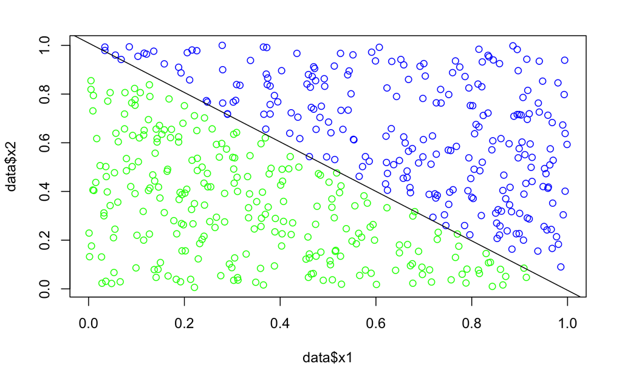

```r
color <- rep("blue", dim(x)[1])
color[which(data$label == -1)] <- "green"

plot(data$x1, data$x2, col=color)

# Following instruction plots the perceptron decision boundary:
# w1 + w2*x1 + w3*x2 = 0
# x2 = -w1/w3 - (w2/w3)*x1
abline(-weight[1]/weight[3],-weight[2]/weight[3])
```

In this case, the **error** is zero from iteration **#4** onwards.